# 02.Arduino Primer

## Basic Arduino Anatomy

Shown below in Figure 1 are the highlights of the Arduino Uno anatomy.

Figure 1: Basic Anatomy of Arduino Uno

[figure not shown]

## USB Communication

Shown below in Figure 2 are the USB communication paths in the Arduino.

Figure 2: Arduino USB Communication

[figure not shown]

## Power System

Shown below in Figure 3 is the Arduino power connections.

Figure 3: Arduino Power System

[figure not shown]

## Pulse Width Modulation

Shown below in Figure 4 is the Arduino pulse width modulation connections.

Figure 4: Arduino Pulse Width Modulation Connections

[figure not shown]

Figure 5: AM and FM signals

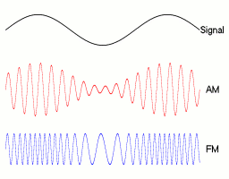

Figure 6: PWM signal

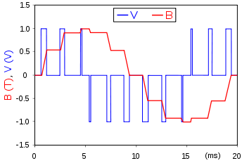

## Serial Peripheral Interface

Shown below in Figure 7 is the Arduino serial peripheral interface.

Figure 7: Arduino Serial Peripheral Interface Connections

[figure not shown]

Table 1: Arduino SPI pins

| PIN 10 | SS or CS | Slave or Chip Select |
| --- | --- | --- |
| PIN 11 | MOSI | Master Out/Slave In |
| PIN 12 | MISO | Master In/Slave Out |
| PIN 13 | SCK or SCLK | Serial Clock |

Figure 8: SPI Configuration with Multiple Slaves

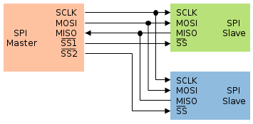

## Analog to Digital Converter

Shown below in Figure 9 is the Arduino analog to digital converter system.

Figure 9: Arduino Analog to Digital Converter

[figure not shown]

## Inter-Integrated Circuit

Shown below in Figure 10 is the Arduino inter-integrated circuit connections.

Figure 10: Arduino Inter-Integrated Circuit Connections

[figure not shown]

Figure 11: Inter-Integrated Circuit Configuration

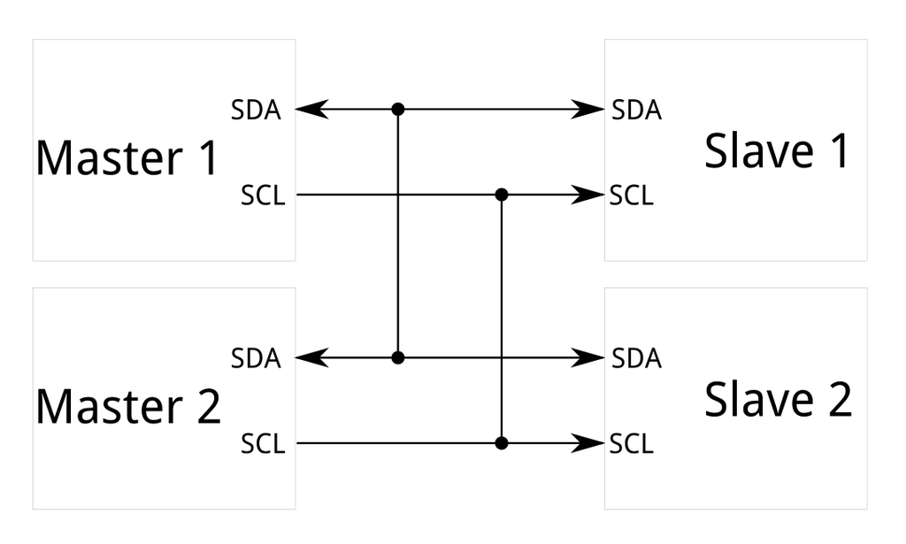

## Pin Out Summary

Shown below in Figure 12 is a summary of all the Arduino pins.

Figure 12: Arduino Pins Cheat Sheet

[figure not shown]

Shown below in Table 2 is a summary of all the Arduino Uno specifications.

Table 2: Arduino Uno Specifications

| Operating Voltage | $5 V$ |
| --- | --- |
| Input Voltage (recommended) | $7$ - $12 V$ |
| Digital I/O Pins | 14 |
| PWM Digital I/O Pins | 6 |
| Analog Input Pins | 6 |
| DC Current per I/O Pin | $20 mA$ |
| DC Current for $3.3 V$ Pin | $50 mA$ |
| Flash Memory | 32KB (minus 0.5KB for bootloader) |
| SRAM | 2KB |
| EEPROM | 1KB |
| Clock Speed | 16MHz |

## Programming the Arduino

Shown below in Figure 13 is the Arduino IDE that is used to program the Arduino.

Figure 13: Arduino IDE

[figure not shown]

## Arduino Language Data Types

Shown below in Table 3 are some of the various Arduino language data types.

Table 3: Common Arduino Data Types

| Type | Possible Values | Storage Space |
| --- | --- | --- |
| [bool](https://www.arduino.cc/reference/en/language/variables/data-types/bool/) (Boolean, pronounced boo-lee-uhn) | True or False | 1 byte |
| [byte](https://www.arduino.cc/reference/en/language/variables/data-types/byte/) | 0 to 255 | 1 byte |
| [int](https://www.arduino.cc/reference/en/language/variables/data-types/int/) | -32,768 to 32767 | 2 bytes |
| [float](https://www.arduino.cc/reference/en/language/variables/data-types/float/) | -3.4028235E+38 to 3.4028235E+38 | 4 bytes |
| [char](https://www.arduino.cc/reference/en/language/variables/data-types/char/) | Stores a character value (i.e. A, B, C, >, %, etc.) | 1 byte |
| [array](https://www.arduino.cc/reference/en/language/variables/data-types/array/) | A collection of variables | Depends |
| [string](https://www.arduino.cc/reference/en/language/variables/data-types/string/) | An array of char values | Depends |

Shown below in Figure 14 is a summary of the common Arduino language commands.

Figure 14: Arduino Cheat Sheet

[figure not shown]

## Useful Resources

- Arduino website
  - [Main Site](https://www.arduino.cc/)
  - [Arduino Uno R3 Product Page](https://store.arduino.cc/usa/arduino-uno-rev3)
  - [Arduino IDE Download](https://www.arduino.cc/en/Main/Software)
  - [Getting Started Guide](https://www.arduino.cc/en/Guide/HomePage)
  - [Online Tutorials](https://www.arduino.cc/en/Tutorial/HomePage)
  - [Language Reference](https://www.arduino.cc/reference/en/)
  - [Forum](https://forum.arduino.cc/)
- Sparkfun website
  - [Main Site](https://www.sparkfun.com/)
  - [Online Tutorials](https://learn.sparkfun.com/tutorials)
  - [What Is An Arduino?](https://learn.sparkfun.com/tutorials/what-is-an-arduino)
- Adafruit website
  - [Main Site](https://www.adafruit.com/)
  - [Online Tutorials](https://learn.adafruit.com/)
  - [Arduino: Getting Started](https://learn.adafruit.com/lesson-0-getting-started?view=all)
  - [Arduino Tips, Tricks, and Techniques](https://learn.adafruit.com/arduino-tips-tricks-and-techniques?view=all)